# Swaraj_EDA_Assignment_2

**Answer the following questions for the given US census data.**

Instructions:

- Drop duplicate records if present.
- Create visualizations where ever necessary.
- Submit your work in Jupyter Notebook and in HTML format with all the results.

**Data Dictionary:**

Unique values of features:

- `age`: continuous.
- `workclass`: Private, Self-emp-not-inc, Self-emp-inc, Federal-gov, Local-gov, State-gov, Without-pay, Never-worked.
- `fnlwgt`: continuous.
- `education`: Bachelors, Some-college, 11th, HS-grad, Prof-school, Assoc-acdm, Assoc-voc, 9th, 7th-8th, 12th, Masters, 1st-4th, 10th, Doctorate, 5th-6th, Preschool.
- `education-num`: continuous.
- `marital-status`: Married-civ-spouse, Divorced, Never-married, Separated, Widowed, Married-spouse-absent, Married-AF-spouse.
- `occupation`: Tech-support, Craft-repair, Other-service, Sales, Exec-managerial, Prof-specialty, Handlers-cleaners, Machine-op-inspct, Adm-clerical, Farming-fishing, Transport-moving, Priv-house-serv, Protective-serv, Armed-Forces.
- `relationship`: Wife, Own-child, Husband, Not-in-family, Other-relative, Unmarried.
- `race`: White, Asian-Pac-Islander, Amer-Indian-Eskimo, Other, Black.
- `sex`: Female, Male.
- `capital-gain`: continuous.
- `capital-loss`: continuous.
- `hours-per-week`: continuous.
- `native-country`: United-States, Cambodia, England, Puerto-Rico, Canada, Germany, Outlying-US(Guam-USVI-etc), India, Japan, Greece, South, China, Cuba, Iran, Honduras, Philippines, Italy, Poland, Jamaica, Vietnam, Mexico, Portugal, Ireland, France, Dominican-Republic, Laos, Ecuador, Taiwan, Haiti, Columbia, Hungary, Guatemala, Nicaragua, Scotland, Thailand, Yugoslavia, El-Salvador, Trinadad&Tobago, Peru, Hong, Holand-Netherlands.
- `salary`: >50K,<=50K

```python
import pandas as pd
import numpy as np
import seaborn as sns
import matplotlib.pyplot as plt
%matplotlib inline
```

```python
df = pd.read_csv(r"EDA_Assignment2.csv", encoding ="latin1")
```

```python
df
```

|  | age | workclass | fnlwgt | education | education-num | marital-status | occupation | relationship | race | sex | capital-gain | capital-loss | hours-per-week | native-country | salary |
| --- | --- | --- | --- | --- | --- | --- | --- | --- | --- | --- | --- | --- | --- | --- | --- |
| 0 | 39 | State-gov | 77516 | Bachelors | 13 | Never-married | Adm-clerical | Not-in-family | White | Male | 2174 | 0 | 40 | United-States | <=50K |
| 1 | 50 | Self-emp-not-inc | 83311 | Bachelors | 13 | Married-civ-spouse | Exec-managerial | Husband | White | Male | 0 | 0 | 13 | United-States | <=50K |
| 2 | 38 | Private | 215646 | HS-grad | 9 | Divorced | Handlers-cleaners | Not-in-family | White | Male | 0 | 0 | 40 | United-States | <=50K |
| 3 | 53 | Private | 234721 | 11th | 7 | Married-civ-spouse | Handlers-cleaners | Husband | Black | Male | 0 | 0 | 40 | United-States | <=50K |
| 4 | 28 | Private | 338409 | Bachelors | 13 | Married-civ-spouse | Prof-specialty | Wife | Black | Female | 0 | 0 | 40 | Cuba | <=50K |
| ... | ... | ... | ... | ... | ... | ... | ... | ... | ... | ... | ... | ... | ... | ... | ... |
| 32556 | 27 | Private | 257302 | Assoc-acdm | 12 | Married-civ-spouse | Tech-support | Wife | White | Female | 0 | 0 | 38 | United-States | <=50K |
| 32557 | 40 | Private | 154374 | HS-grad | 9 | Married-civ-spouse | Machine-op-inspct | Husband | White | Male | 0 | 0 | 40 | United-States | >50K |
| 32558 | 58 | Private | 151910 | HS-grad | 9 | Widowed | Adm-clerical | Unmarried | White | Female | 0 | 0 | 40 | United-States | <=50K |
| 32559 | 22 | Private | 201490 | HS-grad | 9 | Never-married | Adm-clerical | Own-child | White | Male | 0 | 0 | 20 | United-States | <=50K |
| 32560 | 52 | Self-emp-inc | 287927 | HS-grad | 9 | Married-civ-spouse | Exec-managerial | Wife | White | Female | 15024 | 0 | 40 | United-States | >50K |

```python
df.shape
```

[output not shown]

```python
df.isnull().sum()
```

```
age               0
workclass         0
fnlwgt            0
education         0
education-num     0
marital-status    0
occupation        0
relationship      0
race              0
sex               0
capital-gain      0
capital-loss      0
hours-per-week    0
native-country    0
salary            0
dtype: int64
```

```python
df.duplicated().sum()
```

```
24
```

```python
df=df.drop_duplicates()
df
```

|  | age | workclass | fnlwgt | education | education-num | marital-status | occupation | relationship | race | sex | capital-gain | capital-loss | hours-per-week | native-country | salary |
| --- | --- | --- | --- | --- | --- | --- | --- | --- | --- | --- | --- | --- | --- | --- | --- |
| 0 | 39 | State-gov | 77516 | Bachelors | 13 | Never-married | Adm-clerical | Not-in-family | White | Male | 2174 | 0 | 40 | United-States | <=50K |
| 1 | 50 | Self-emp-not-inc | 83311 | Bachelors | 13 | Married-civ-spouse | Exec-managerial | Husband | White | Male | 0 | 0 | 13 | United-States | <=50K |
| 2 | 38 | Private | 215646 | HS-grad | 9 | Divorced | Handlers-cleaners | Not-in-family | White | Male | 0 | 0 | 40 | United-States | <=50K |
| 3 | 53 | Private | 234721 | 11th | 7 | Married-civ-spouse | Handlers-cleaners | Husband | Black | Male | 0 | 0 | 40 | United-States | <=50K |
| 4 | 28 | Private | 338409 | Bachelors | 13 | Married-civ-spouse | Prof-specialty | Wife | Black | Female | 0 | 0 | 40 | Cuba | <=50K |
| ... | ... | ... | ... | ... | ... | ... | ... | ... | ... | ... | ... | ... | ... | ... | ... |
| 32556 | 27 | Private | 257302 | Assoc-acdm | 12 | Married-civ-spouse | Tech-support | Wife | White | Female | 0 | 0 | 38 | United-States | <=50K |
| 32557 | 40 | Private | 154374 | HS-grad | 9 | Married-civ-spouse | Machine-op-inspct | Husband | White | Male | 0 | 0 | 40 | United-States | >50K |
| 32558 | 58 | Private | 151910 | HS-grad | 9 | Widowed | Adm-clerical | Unmarried | White | Female | 0 | 0 | 40 | United-States | <=50K |
| 32559 | 22 | Private | 201490 | HS-grad | 9 | Never-married | Adm-clerical | Own-child | White | Male | 0 | 0 | 20 | United-States | <=50K |
| 32560 | 52 | Self-emp-inc | 287927 | HS-grad | 9 | Married-civ-spouse | Exec-managerial | Wife | White | Female | 15024 | 0 | 40 | United-States | >50K |

32537 rows × 15 columns

```python
df.duplicated().sum()
```

```
0
```

**1. How many men and women (*sex* feature) are represented in this dataset?**

```python
df['sex'].value_counts()
```

```
Male      21775
Female    10762
Name: sex, dtype: int64
```

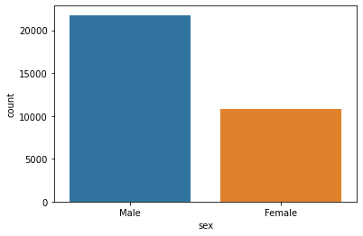

```python
sns.countplot(x='sex',data =df)
```

**2. What is the average age (*age* feature) of women?**

```python
df.loc[df['sex'] == 'Female', 'age'].mean()
```

```
36.864709161865825
```

**3. What is the proportion of German citizens (*native-country* feature)?**

```python
100*(float((df['native-country']== "Germany").sum())/df.shape[0])
```

```
0.4210591019454774
```

**4-5. What are mean value and standard deviation of the age of those who recieve more than 50K per year (*salary* feature) and those who receive less than 50K per year?**

```python
age_1 = df.loc[df['salary']=='>50K','age']
age_2 = df.loc[df['salary']== '<=50K','age']
age_1_mean=age_1.mean()
age_2_mean=age_2.mean()
age_1_std=age_1.std()
age_2_std=age_2.std()
```

```python
print("Average age for those who are earnig more than >50K is: ",age_1_mean,"and it's standard deviation",age_1_std)
print("Average age for those who are earnig less than <=50K is: ",age_2_mean,"and it's standard deviation",age_2_std)
```

```
Average age for those who are earnig more than >50K is:  44.25092486286516 and it's standard deviation 10.52010208815647
Average age for those who are earnig less than <=50K is:  36.78739169163495 and it's standard deviation 14.017334627959187
```

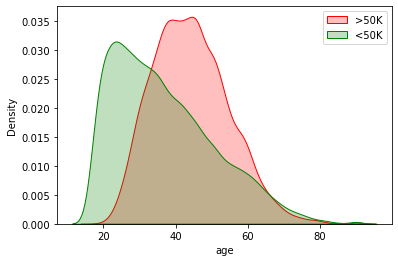

```python
sns.kdeplot(data =df[df['salary']=='>50K']['age'],color='r',shade = True,label='>50K')
sns.kdeplot(data =df[df['salary']=='<=50K']['age'],color='g',shade = True,label='<50K')
plt.legend()
```

**6. Is it true that people who receive more than 50k have at least high school education? (*education - Bachelors, Prof-school, Assoc-acdm, Assoc-voc, Masters* or *Doctorate* feature)**

```python
d1=df.loc[df['salary']=='>50K','education'].unique()
d1
```

```
array(['HS-grad', 'Masters', 'Bachelors', 'Some-college', 'Assoc-voc',
       'Doctorate', 'Prof-school', 'Assoc-acdm', '7th-8th', '12th',
       '10th', '11th', '9th', '5th-6th', '1st-4th'], dtype=object)
```

**7. Display statistics of age for each race (*race* feature) and each gender. Use *groupby()* and *describe()*. Find the maximum age of men of *Amer-Indian-Eskimo* race.**

```python
df.groupby(['race','sex'])['age'].describe()
```

| race | sex | count | mean | std | min | 25% | 50% | 75% | max |
| --- | --- | --- | --- | --- | --- | --- | --- | --- | --- |
| Amer-Indian-Eskimo | Female | 119.0 | 37.117647 | 13.114991 | 17.0 | 27.0 | 36.0 | 46.00 | 80.0 |
|  | Male | 192.0 | 37.208333 | 12.049563 | 17.0 | 28.0 | 35.0 | 45.00 | 82.0 |
| Asian-Pac-Islander | Female | 346.0 | 35.089595 | 12.300845 | 17.0 | 25.0 | 33.0 | 43.75 | 75.0 |
|  | Male | 692.0 | 39.000000 | 12.746669 | 18.0 | 29.0 | 37.0 | 46.00 | 90.0 |
| Black | Female | 1555.0 | 37.854019 | 12.637197 | 17.0 | 28.0 | 37.0 | 46.00 | 90.0 |
|  | Male | 1567.0 | 37.699426 | 12.880714 | 17.0 | 27.0 | 36.0 | 46.00 | 90.0 |
| Other | Female | 109.0 | 31.678899 | 11.631599 | 17.0 | 23.0 | 29.0 | 39.00 | 74.0 |
|  | Male | 162.0 | 34.654321 | 11.355531 | 17.0 | 26.0 | 32.0 | 42.00 | 77.0 |
| White | Female | 8633.0 | 36.819646 | 14.331045 | 17.0 | 25.0 | 35.0 | 46.00 | 90.0 |
|  | Male | 19162.0 | 39.656560 | 13.436249 | 17.0 | 29.0 | 38.0 | 49.00 | 90.0 |

**8. Among whom the proportion of those who earn a lot(>50K) is more: among married or single men (*marital-status* feature)? Consider married those who have a *marital-status* starting with *Married* (Married-civ-spouse, Married-spouse-absent or Married-AF-spouse), the rest are considered bachelors.**

```python
data_male=df.loc[df['sex']=='Male']
bachelor=data_male['marital-status'].isin(['Never-married','Divorced','Seperated','Widow','Married-AF-spouse','Married-civ-spouse'])
married=data_male['marital-status'].str.startswith('Married')
rich_bach=data_male.loc[(df['salary']=='>50K')& bachelor].shape[0]
rich_mar= data_male.loc[(df['salary']=='>50K')& married].shape[0]
print(rich_mar,'married men and',rich_bach,'bachelor are earning >50K')
```

```
5963 married men and 6549 bachelor are earning >50K
```

**9. What is the maximum number of hours a person works per week (*hours-per-week* feature)? How many people work such a number of hours and what is the percentage of those who earn a lot among them?**

```python
hours =df['hours-per-week'].max()
print('Maximum number of hours a person works is:',hours)
work = df.loc[df['hours-per-week']==hours].shape[0]
print('Number of People Work hard are:',work)
(float(df.loc[(df['hours-per-week']==hours) & (df['salary'] == '>50K')].shape[0])/work)*100
```

```
Maximum number of hours a person works is: 99
Number of People Work hard are: 85
```

```
29.411764705882355
```

**10. Count the average time of work (*hours-per-week*) those who earning a little and a lot (*salary*) for each country (*native-country*).**

```python
count = df.groupby(['native-country','salary'])['hours-per-week'].mean().reset_index()
count
```

|  | native-country | salary | hours-per-week |
| --- | --- | --- | --- |
| 0 | ? | <=50K | 40.165138 |
| 1 | ? | >50K | 45.547945 |
| 2 | Cambodia | <=50K | 41.416667 |
| 3 | Cambodia | >50K | 40.000000 |
| 4 | Canada | <=50K | 37.914634 |
| ... | ... | ... | ... |
| 77 | United-States | >50K | 45.505789 |
| 78 | Vietnam | <=50K | 37.193548 |
| 79 | Vietnam | >50K | 39.200000 |
| 80 | Yugoslavia | <=50K | 41.600000 |
| 81 | Yugoslavia | >50K | 49.500000 |

82 rows × 3 columns

**11. Which workclass gets the highest salary?**

```python
df.groupby('workclass') ['salary'].max()
```

```
workclass
?                    >50K
Federal-gov          >50K
Local-gov            >50K
Never-worked        <=50K
Private              >50K
Self-emp-inc         >50K
Self-emp-not-inc     >50K
State-gov            >50K
Without-pay         <=50K
Name: salary, dtype: object
```

**12. Draw your own insights from the given data apart from the given list of questions.**

1The Male participation is much more than female. 2.The average age of the Male is 39 where as the average age of Female is 37. 3.The average age who earn more than 50K salary is 44 years. 4.The average age who earn less than 50K salary is 37 years.